# Assignment8

July 17, 2018

## Contents

- Data Preparation
- GLM
  - Open_Close_PctChange
  - Daily_Return
- Random Forest
  - Open_Close_PctChange
  - Daily_Return
- Final Results & Business Insights

## Data Preparation

## Data - Feature Engineering

After bringing the stock.csv data, I created features to build a model.  
I additionally created `xxxx_SMA10` features which represent a Simple Moving Average.

| Date | Open | High | Low | Close | Volume | OpenInt | Symbol | Open_Close_PctChange | Open_Close_Delt | Open_Change | High_Change | Low_Change | Close_Change | Volume_Change | Daily_Return | Open_PctChange | High_PctChange | Low_PctChange | Close_PctChange | Volume_PctChange | Open_Mean10 | High_Mean10 | Low_Mean10 | Close_Mean10 | Volume_Mean10 | Open_Mean10_R | High_Mean10_R | Low_Mean10_R | Close_Mean10_R | … |
| --- | --- | --- | --- | --- | --- | --- | --- | --- | --- | --- | --- | --- | --- | --- | --- | --- | --- | --- | --- | --- | --- | --- | --- | --- | --- | --- | --- | --- | --- | --- |
| 1999-11-18 | 30.713 | 33.754 | 27.002 | 29.702 | 66277506 | 0 | A | -3.291766 | -3.291766 | NA | NA | NA | NA | NA | 0.9670823 | NA | NA | NA | NA | NA | NA | NA | NA | NA | NA | NA | NA | NA | NA | … |
| 1999-11-18 | 30.713 | 33.754 | 27.002 | 29.702 | 66277506 | 0 | A | -3.291766 | -3.291766 | 0.000 | 0.000 | 0.000 | 0.000 | 0 | 0.9670823 | 0.000000 | 0.000000 | 0.0000000 | 0.000000 | 0.00000 | NA | NA | NA | NA | NA | NA | NA | NA | NA | … |
| 1999-11-19 | 28.986 | 29.027 | 26.872 | 27.257 | 16142920 | 0 | A | -5.964949 | -5.964949 | -1.727 | -4.727 | -0.130 | -2.445 | -50134586 | 0.9403505 | -5.623026 | -14.004266 | -0.4814458 | -8.231769 | -75.64344 | NA | NA | NA | NA | NA | NA | NA | NA | NA | … |
| 1999-11-19 | 28.986 | 29.027 | 26.872 | 27.257 | 16142920 | 0 | A | -5.964949 | -5.964949 | 0.000 | 0.000 | 0.000 | 0.000 | 0 | 0.9403505 | 0.000000 | 0.000000 | 0.0000000 | 0.000000 | 0.00000 | NA | NA | NA | NA | NA | NA | NA | NA | NA | … |
| 1999-11-22 | 27.886 | 29.702 | 27.044 | 29.702 | 6970266 | 0 | A | 6.512228 | 6.512228 | -1.100 | 0.675 | 0.172 | 2.445 | -9172654 | 1.0651223 | -3.794935 | 2.325421 | 0.6400714 | 8.970173 | -56.82153 | 28.6712 | 30.0476 | 26.9844 | 28.2760 | 20170984 | NA | NA | NA | NA | … |
| 1999-11-22 | 27.886 | 29.702 | 27.044 | 29.702 | 6970266 | 0 | A | 6.512228 | 6.512228 | 0.000 | 0.000 | 0.000 | 0.000 | 0 | 1.0651223 | 0.000000 | 0.000000 | 0.0000000 | 0.000000 | 0.00000 | 28.3593 | 29.4734 | 27.0351 | 28.0865 | 13726497 | NA | NA | NA | NA | … |

## Data - Sample Range

I selected the year between \(2011\) and \(2012\) for this assignment.

| Year | QtrYear |
| --- | --- |
| 2011 | 2011-Q1 |
| 2011 | 2011-Q2 |
| 2011 | 2011-Q3 |
| 2011 | 2011-Q4 |
| 2012 | 2012-Q1 |
| 2012 | 2012-Q2 |
| 2012 | 2012-Q3 |
| 2012 | 2012-Q4 |

## Data - Train and Test

As I selected year \(2011\) and \(2012\) I have five sets of training and testing.

```
## [1] "Set:"
## [1] "2011-Q1" "2011-Q2" "2011-Q3"
## [1] "2011-Q4"
## [1] "Set:"
## [1] "2011-Q2" "2011-Q3" "2011-Q4"
## [1] "2012-Q1"
## [1] "Set:"
## [1] "2011-Q3" "2011-Q4" "2012-Q1"
## [1] "2012-Q2"
## [1] "Set:"
## [1] "2011-Q4" "2012-Q1" "2012-Q2"
## [1] "2012-Q3"
## [1] "Set:"
## [1] "2012-Q1" "2012-Q2" "2012-Q3"
## [1] "2012-Q4"
```

## Data - Train and Test

I am going to quickly check the number of rows in one train/test set.

```
## [1] "The number of cases in the first Train set: 87033"
```

```
## [1] "The number of cases in the first Test set: 29310"
```

## GLM

## Open_Close_PctChange

I trained each 5 train set respectively, and combined the results in one single dataframe.  
I selected **outliers** as those which are larger than 5 standard deviations. I printed out each train set’s RMSE and the number of outliers (combined).

```
## [[1]]
## [1] " Model #1 RMSE: 0.00497542947478524"
##
## [[2]]
## [1] " Model #2 RMSE: 0.00494747251365173"
##
## [[3]]
## [1] " Model #3 RMSE: 0.00310294032266738"
##
## [[4]]
## [1] " Model #4 RMSE: 0.0104049056343688"
##
## [[5]]
## [1] " Model #5 RMSE: 0.020464589411646"
```

## Open_Close_PctChange

I trained each 5 train set respectively, and combined the results in one single dataframe.  
I selected **outliers** as those which are larger than 5 standard deviations. I printed out each train set’s RMSE and the number of outliers (combined).

```
## [1] "The number of outliers (larger than 5 STD) is 100"
```

## Open_Close_PctChange

| date | sector | symbol | qrt_year | predictions | Open_Close_PctChange | diff |
| --- | --- | --- | --- | --- | --- | --- |
| 2011-10-04 | Financials | AFL | 2011-Q4 | 9.624317 | 9.649588 | -0.02527 |
| 2011-10-04 | Information Technology | AKAM | 2011-Q4 | 12.195218 | 12.227074 | -0.03186 |
| 2011-12-22 | Information Technology | AKAM | 2011-Q4 | 14.980756 | 15.018182 | -0.03743 |
| 2011-10-04 | Health Care | ALGN | 2011-Q4 | 12.730307 | 12.762973 | -0.03267 |
| 2011-10-03 | Information Technology | AMD | 2011-Q4 | -9.915177 | -9.940358 | 0.02518 |
| 2011-10-05 | Energy | ANDV | 2011-Q4 | 12.756849 | 12.789302 | -0.03245 |

## Daily_Return

I conducted the same modeling for the `Daily_Return` variable as well.  
Again, I printed RMSE and the number of outliers.

```
## [[1]]
## [1] " Model #1 RMSE: 6.13765220008324e-05"
##
## [[2]]
## [1] " Model #2 RMSE: 4.81382817352538e-05"
##
## [[3]]
## [1] " Model #3 RMSE: 6.95141984438826e-05"
##
## [[4]]
## [1] " Model #4 RMSE: 0.000222171813574624"
##
## [[5]]
## [1] " Model #5 RMSE: 0.000176356698213022"
```

## Daily_Return

I conducted the same modeling for the `Daily_Return` variable as well.  
Again, I printed RMSE and the number of outliers.

```
## [1] "The number of outliers (larger than 5 STD) is 112"
```

## Daily_Return

| date | sector | symbol | qrt_year | predictions | Daily_Return | diff |
| --- | --- | --- | --- | --- | --- | --- |
| 2011-10-04 | Information Technology | AKAM | 2011-Q4 | 1.1218859 | 1.1222707 | -0.00038 |
| 2011-12-22 | Information Technology | AKAM | 2011-Q4 | 1.1497092 | 1.1501818 | -0.00047 |
| 2011-10-04 | Health Care | ALGN | 2011-Q4 | 1.1272281 | 1.1276297 | -0.00040 |
| 2011-10-28 | Health Care | ALGN | 2011-Q4 | 1.1007062 | 1.1010242 | -0.00032 |
| 2011-10-03 | Information Technology | AMD | 2011-Q4 | 0.9009089 | 0.9005964 | 0.00031 |
| 2011-10-05 | Energy | ANDV | 2011-Q4 | 1.1274905 | 1.1278930 | -0.00040 |

## Random Forest

## Random Forest

Although I am going to use the same target variables (`Open_Close_PctChange`, and `Daily_Return`)  
for the random forest, I selected some of the original variables as predictive variables.  
This is because non-valuable variables caused worse results for the random forests models.

## Open_Close_PctChange

As we can see from the below result, around \(100\) outliers are detected in this case.

```
## [1] "The number of outliers (larger than 5 STD) is 103"
```

## Open_Close_PctChange

The below table shows detected outliers.

| date | sector | symbol | qrt_year | predictions_rf | Open_Close_PctChange | diff |
| --- | --- | --- | --- | --- | --- | --- |
| 2011-10-04 | Real Estate | AIV | 2011-Q4 | -0.7627541 | 8.894687 | -9.65744 |
| 2011-10-04 | Information Technology | AKAM | 2011-Q4 | 0.6958273 | 12.227074 | -11.53125 |
| 2011-12-22 | Information Technology | AKAM | 2011-Q4 | 1.1365491 | 15.018182 | -13.88163 |
| 2011-10-04 | Health Care | ALGN | 2011-Q4 | 0.3668637 | 12.762973 | -12.39611 |
| 2011-10-28 | Health Care | ALGN | 2011-Q4 | 0.1286754 | 10.102421 | -9.97375 |
| 2011-10-04 | Information Technology | AMD | 2011-Q4 | -4.9050665 | 6.787330 | -11.69240 |

## Daily_Return

```
## [1] "The number of outliers (larger than 5 STD) is 97"
```

| date | sector | symbol | qrt_year | predictions_rf | Daily_Return | diff |
| --- | --- | --- | --- | --- | --- | --- |
| 2011-10-04 | Information Technology | AKAM | 2011-Q4 | 1.0111305 | 1.122271 | -0.11114 |
| 2011-12-22 | Information Technology | AKAM | 2011-Q4 | 1.0035883 | 1.150182 | -0.14659 |
| 2011-10-04 | Health Care | ALGN | 2011-Q4 | 1.0058106 | 1.127630 | -0.12182 |
| 2011-10-04 | Information Technology | AMD | 2011-Q4 | 0.9607416 | 1.067873 | -0.10713 |
| 2011-10-05 | Energy | ANDV | 2011-Q4 | 1.0300230 | 1.127893 | -0.09787 |
| 2011-10-04 | Industrials | AYI | 2011-Q4 | 1.0011235 | 1.121724 | -0.12060 |

## Business Insights

## Daily_Return Results

Since both showed pretty much similar results, I will show only `Daily_Return` here.  
I plotted the combined results from the two model (GLM and Random Forest) with the real values.

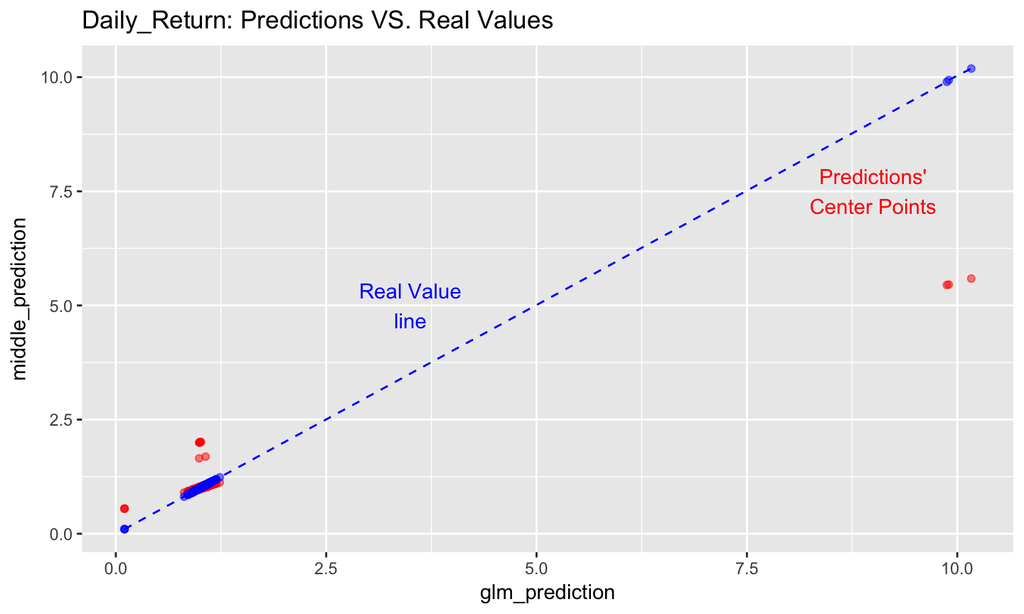

## Error

If we calculate the euclidean distance between  
1. GLM Predictions VS. Real Values  
2. RF Predictions VS. Real Values  
3. Averaged Predictions VS. Real Values  
As we can find from the below results, **glm** tends to predict more closely to the real values.

```
## [1] "Error with the GLM model: 0.0519546759388578"
```

```
## [1] "Error with the Random Forest model: 17.3312884094912"
```

```
## [1] "Error with the Combined model: 8.68949914483965"
```

## Final Insights

Finally, I inner joined the two outlier results (`glm_outliers` and `rf_outliers`) to find the commonly detected outliers.  
Instead of looking at individual values, I decided to look at the `Sector` of the outliers, and look at the percentage of the outliers per each **sector**.  
This would be interesting information for investors who would like to invest stocks based on their *risk sensitivity*.

| sector | num_count.x | num_count.y | percentage |
| --- | --- | --- | --- |
| Consumer Discretionary | 13 | 23320 | 0.056 |
| Consumer Staples | NA | 9635 | NA |
| Energy | 7 | 9243 | 0.076 |
| Financials | 4 | 20031 | 0.020 |
| Health Care | 14 | 18154 | 0.077 |
| Industrials | 11 | 19380 | 0.057 |
| Information Technology | 22 | 20444 | 0.108 |
| Materials | 3 | 7512 | 0.040 |
| Real Estate | 1 | 9703 | 0.010 |
| Telecommunication Services | NA | 939 | NA |
| Utilities | 5 | 8764 | 0.057 |